# stm_model_estimation

## В structural topic modeling учитываются доп. переменные ( covariates).

**В своей модели я взяла два ковариата Time и Type ( новость из внутренней повестки или о внешней повестке ( разделялось по метаданным из NY api - там даются тэги ))

# Загрузим результаты модели

```r
load("~/Курсач/R_notebooks/stmfit.RData")
load("~/Курсач/R_notebooks/out.RData")
load("~/Курсач/R_notebooks/estimeffects.RData")
```

# Посмотрим на распределение топиков

```r
library(scales)
library(tidytext)
library(tidyverse)
library(dplyr)
library(ggplot2)
library(ggthemes)
td_gamma <- tidy(stmFit, matrix = 'theta')
td_beta <- tidy(stmFit)
top_terms <- td_beta %>%
  arrange(beta) %>%
  group_by(topic) %>%
  top_n(7, beta) %>%
  arrange(-beta) %>%
  select(topic, term) %>%
  summarise(terms = list(term)) %>%
  mutate(terms = map(terms, paste, collapse = ", ")) %>%
  unnest()
gamma_terms <- td_gamma %>%
  group_by(topic) %>%
  summarise(gamma = mean(gamma)) %>%
  arrange(desc(gamma)) %>%
  left_join(top_terms, by = "topic") %>%
  mutate(topic = paste0("Topic ", topic),
         topic = reorder(topic, gamma))
```

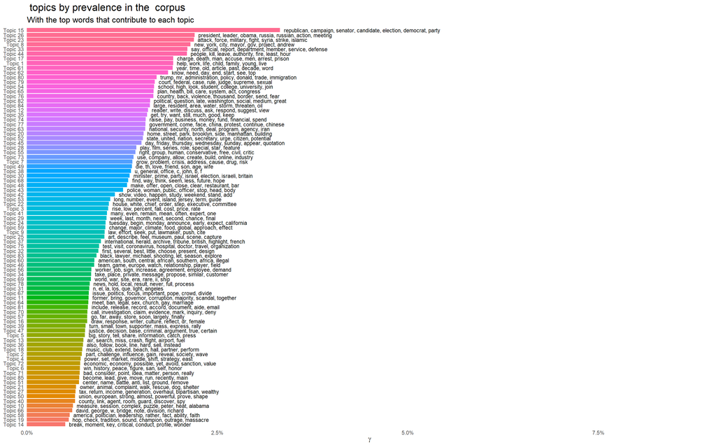

```r
gamma_terms %>%
  top_n(85, gamma) %>%
  ggplot(aes(topic, gamma, label = terms, fill = topic)) +
  geom_col(show.legend = FALSE) +
  geom_text(hjust = 0, nudge_y = 0.0005, size = 3,
            family = "IBMPlexSans") +
  coord_flip() +
  scale_y_continuous(expand = c(0,0),
                     limits = c(0, 0.09),
                     labels = percent_format()) +
  theme_tufte(base_family = "IBMPlexSans", ticks = FALSE) +
  theme(plot.title = element_text(size = 16,
                                  family="IBMPlexSans-Bold"),
        plot.subtitle = element_text(size = 13)) +
  labs(x = NULL, y = expression(gamma),
       title = " topics by prevalence in the  corpus",
       subtitle = "With the top words that contribute to each topic")
```

**На что смотрим тут:**

Смотрим есть ли темы " имеющие смысл" в нижних зонах распределения ( то есть представленных в меньших количествах)

**Бросаются в глаза из сине-зеленой зоны (более менее средней)**

```r
library(stm)
labelTopics(stmFit,topics=c(7,30,43,22,9,59,75,60,56,67,64,83))
```

```
## Topic 7 Top Words:
##       Highest Prob: grow, problem, crisis, address, cause, drug, risk
##       FREX: grow, problem, risk, poor, housing, treatment, condition
##       Lift: addiction, affordability, antidepressant, bacterial, clinical, convulsion, density
##       Score: problem, crisis, cause, drug, address, grow, risk
## Topic 30 Top Words:
##       Highest Prob: minister, prime, party, israel, election, israeli, britain
##       FREX: minister, prime, israeli, india, palestinian, indian, parliament
##       Lift: abadi, andhra, ardern, benny, gibraltar, imran, inconclusive
##       Score: minister, prime, israeli, israel, palestinian, party, britain
## Topic 43 Top Words:
##       Highest Prob: police, woman, public, officer, stop, head, body
##       FREX: police, woman, officer, stop, body, veteran, affair
##       Lift: dashboard, dereliction, affair, beard, duty, frisk, handgun
##       Score: police, woman, officer, public, stop, body, head
## Topic 22 Top Words:
##       Highest Prob: house, white, chief, order, step, executive, committee
##       FREX: house, white, chief, step, committee, representative, speaker
##       Lift: anticipated, baroni, branding, cipollone, describes, disparage, hotly
##       Score: house, white, chief, executive, committee, order, representative
## Topic 9 Top Words:
##       Highest Prob: law, effort, seek, put, lawmaker, push, cite
##       FREX: effort, seek, put, push, cite, protection, prevent
##       Lift: intend, bankruptcy, cite, closer, determine, engage, management
##       Score: law, effort, lawmaker, seek, put, push, enforcement
## Topic 59 Top Words:
##       Highest Prob: change, major, climate, food, global, approach, effect
##       FREX: change, major, climate, food, global, approach, effect
##       Lift: atmospheric, attractive, boom, carbon, emission, faster, growing
##       Score: change, climate, food, global, major, effect, reduce
## Topic 75 Top Words:
##       Highest Prob: test, visit, coronavirus, hospital, doctor, travel, organization
##       FREX: hospital, doctor, travel, organization, patient, spread, trip
##       Lift: bag, bellevue, cardiovascular, contagion, covid, emerge, epicenter
##       Score: coronavirus, visit, hospital, test, doctor, travel, virus
## Topic 60 Top Words:
##       Highest Prob: american, south, central, african, southern, africa, illegal
##       FREX: american, south, african, africa, illegal, destroy, republic
##       Lift: asian, blow, comrade, dongguan, enemy, hee, nelson
##       Score: american, south, african, central, africa, southern, republic
## Topic 56 Top Words:
##       Highest Prob: worker, job, sign, increase, agreement, employee, demand
##       FREX: worker, job, sign, increase, require, labor, growth
##       Lift: relatively, alexandria, chrysler, contingency, cortez, decent, excuse
##       Score: worker, job, sign, increase, employee, agreement, require
## Topic 67 Top Words:
##       Highest Prob: issue, politics, focus, important, pope, crowd, divide
##       FREX: issue, politics, focus, important, pope, divide, catholic
##       Lift: fairness, absence, aggrieved, archbishop, archdiocese, basilica, beatify
##       Score: issue, politics, focus, pope, catholic, important, francis
## Topic 64 Top Words:
##       Highest Prob: meet, ban, legal, sex, church, gay, marriage
##       FREX: meet, ban, legal, sex, gay, marriage, couple
##       Lift: accommodate, adopt, afoul, android, app, arranged, bearer
##       Score: meet, sex, marriage, ban, legal, gay, couple
## Topic 83 Top Words:
##       Highest Prob: black, lawyer, michael, shooting, let, season, explore
##       FREX: black, lawyer, michael, shooting, let, explore, grand
##       Lift: denver, laquan, anthropologist, brown, cowboys, dade, dylann
##       Score: michael, lawyer, black, shooting, let, season, jury
```

**Посмотри на темы из самой нижней зоны**

```r
g <- subset(td_beta,td_beta$topic == c(14,58,10,50,27,21,6,4,72))
```

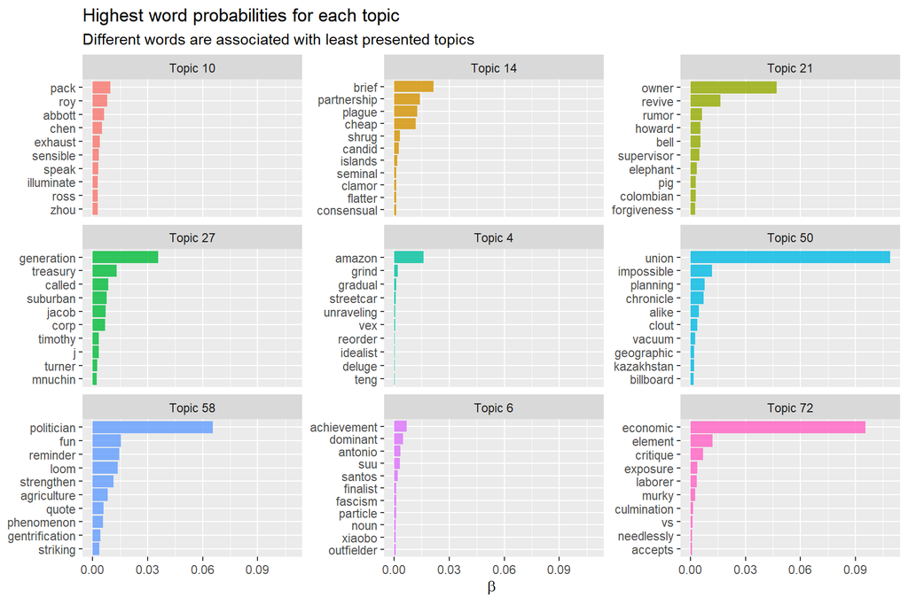

```r
g %>%
    group_by(topic) %>%
    top_n(10, beta) %>%
    ungroup() %>%
    mutate(topic = paste0("Topic ", topic),
           term = reorder_within(term, beta, topic)) %>%
    ggplot(aes(term, beta, fill = as.factor(topic))) +
    geom_col(alpha = 0.8, show.legend = FALSE) +
    facet_wrap(~ topic, scales = "free_y") +
    coord_flip() +
    scale_x_reordered() +
    labs(x = NULL, y = expression(beta),
         title = "Highest word probabilities for each topic",
         subtitle = "Different words are associated with least presented topics")
```

```r
library(stm)
labelTopics(stmFit,topics=c(14,58,10,50,27,21,6,4,72))
```

```
## Topic 14 Top Words:
##       Highest Prob: break, moment, key, critical, conduct, profile, wonder
##       FREX: break, moment, key, critical, conduct, profile, wonder
##       Lift: arguably, authoritarianism, break, brock, candid, caught, communicate
##       Score: break, moment, key, critical, conduct, profile, wonder
## Topic 58 Top Words:
##       Highest Prob: america, politician, leadership, rather, fact, ability, faith
##       FREX: america, politician, rather, fact, ability, faith, probably
##       Lift: ability, aggressive, breakfast, cheat, daimler, disaffect, foolish
##       Score: america, politician, fact, rather, ability, leadership, faith
## Topic 10 Top Words:
##       Highest Prob: measure, session, complex, puzzle, peter, heat, alabama
##       FREX: measure, session, complex, puzzle, heat, alabama, jeff
##       Lift: adversary, expansion, anecdote, brownback, chapter, coaching, crossword
##       Score: measure, puzzle, session, jeff, crossword, complex, alabama
## Topic 50 Top Words:
##       Highest Prob: union, european, strong, almost, powerful, prove, shape
##       FREX: union, strong, almost, powerful, prove, shape, zone
##       Lift: certainty, impossible, mirror, thrive, abbreviated, almost, anxiously
##       Score: european, union, strong, almost, powerful, prove, shape
## Topic 27 Top Words:
##       Highest Prob: tax, return, income, generation, overhaul, bipartisan, wealthy
##       FREX: tax, return, income, generation, overhaul, bipartisan, wealthy
##       Lift: adama, blumenauer, called, callimachi, carried, changed, coercion
##       Score: tax, return, income, generation, overhaul, bipartisan, edward
## Topic 21 Top Words:
##       Highest Prob: owner, animal, complaint, walk, rescue, dog, shelter
##       FREX: owner, animal, complaint, walk, rescue, dog, shelter
##       Lift: rumor, aging, agung, andes, anonymously, apparently, arena
##       Score: animal, owner, dog, rescue, walk, complaint, shelter
## Topic 6 Top Words:
##       Highest Prob: win, history, peace, figure, san, self, honor
##       FREX: history, figure, san, self, honor, winner, award
##       Lift: abiy, dwarf, fil, foray, honor, interplay, medal
##       Score: win, history, san, peace, figure, honor, award
## Topic 4 Top Words:
##       Highest Prob: power, set, market, middle, shift, strategy, east
##       FREX: power, set, market, middle, shift, strategy, voice
##       Lift: aside, barbecue, ease, innovative, kaesong, proxy, size
##       Score: power, set, market, middle, shift, strategy, east
## Topic 72 Top Words:
##       Highest Prob: economic, economy, possible, yet, avoid, sanction, value
##       FREX: economic, possible, yet, avoid, sanction, value, nothing
##       Lift: integration, iranian, lift, nothing, outweigh, tough, apostle
##       Score: economic, possible, yet, sanction, avoid, economy, nothing
```

**Ну и общая сводка по темам для удобства**

```r
library(knitr)
gamma_terms %>%
  select(topic, gamma, terms) %>%
  kable(digits = 3,
        col.names = c("Topic", "Expected topic proportion", "Top 7 terms"))
```

| Topic | Expected topic proportion | Top 7 terms |
| --- | --- | --- |
| Topic 15 | 0.033 | republican, campaign, senator, candidate, election, democrat, party |
| Topic 26 | 0.022 | president, leader, obama, russia, russian, action, meeting |
| Topic 23 | 0.022 | attack, force, military, fight, syria, strike, islamic |
| Topic 8 | 0.021 | new, york, city, mayor, gov, project, andrew |
| Topic 33 | 0.021 | say, official, report, department, member, service, defense |
| Topic 44 | 0.021 | people, kill, leave, authority, fire, least, hour |
| Topic 17 | 0.019 | charge, death, man, accuse, men, arrest, prison |
| Topic 1 | 0.019 | help, work, life, child, family, young, live |
| Topic 61 | 0.019 | year, time, old, article, past, decade, word |
| Topic 62 | 0.019 | know, need, day, end, start, see, top |
| Topic 80 | 0.017 | trump, mr, administration, policy, donald, trade, immigration |
| Topic 79 | 0.017 | court, federal, case, rule, judge, supreme, sexual |
| Topic 54 | 0.017 | school, high, look, student, college, university, join |
| Topic 65 | 0.017 | plan, health, bill, care, system, act, congress |
| Topic 76 | 0.017 | country, back, violence, thousand, border, send, fear |
| Topic 82 | 0.016 | political, question, late, washington, social, medium, great |
| Topic 84 | 0.016 | large, resident, area, water, storm, threaten, oil |
| Topic 12 | 0.016 | reader, write, discuss, ask, respond, suggest, view |
| Topic 35 | 0.016 | get, try, want, still, much, good, keep |
| Topic 74 | 0.016 | raise, pay, business, money, fund, financial, spend |
| Topic 77 | 0.016 | government, come, face, china, protest, continue, chinese |
| Topic 63 | 0.016 | national, security, north, deal, program, agency, iran |
| Topic 20 | 0.015 | home, street, park, brooklyn, side, manhattan, building |
| Topic 52 | 0.015 | state, united, nation, secretary, urge, citizen, potential |
| Topic 45 | 0.015 | day, friday, thursday, wednesday, sunday, appear, quotation |
| Topic 28 | 0.014 | play, film, series, role, special, star, feature |
| Topic 55 | 0.014 | right, group, human, conservative, free, civil, critic |
| Topic 73 | 0.014 | use, company, allow, create, build, online, industry |
| Topic 7 | 0.014 | grow, problem, crisis, address, cause, drug, risk |
| Topic 49 | 0.014 | die, th, love, friend, son, age, wife |

[output cut: 55 more lines]